# Impact of severe Weather events on Health and Economy in US

Sai Karthik Varanasi

January 16, 2017

## Introduction

Severe Weather events cause a significant problems to the public health and cause economic problems for the people in the community. The key task at hand is to prevent these losses due to extreme weather conditions and to take precautionary measures accordingly thorugh the insights obtained from the data.s

## Aim

The aim of this project is to explore the U.S. National Oceanic and Atmospheric Administration’s (NOAA) Storm Database and answer some basic questions about severe weather events and their effect on the population’s health and Economic scenario.

## Synopsis

- The data for this project is collected from the U.S. National Oceanic and Atmospheric Administration’s (NOAA) Storm Database. [Storm Data [47Mb]] (http://www.ncdc.noaa.gov/stormevents/ftp.jsp). (This is a comma-separated-value file compressed via the bzip2 algorithm to reduce its size)
- This database tracks characteristics of major storms and weather events in the United States, including when and where they occur, as well as estimates of any fatalities, injuries, and property damage.
- From the analysis it has been found that between 1950 and 2011:
- **Tornadoes** and **Excessive Heat** are the two most fatal weather events that affect the health of the population in that order.
- **Tornadoes** and**Flash floods** caused a significant damage to the public property and the largest crop losses are caused by **Hails**, followed by **Flash floods**.

## Data Processing

As mentioned above the data is obtained from the U.S. National Oceanic and Atmospheric Administration’s (NOAA) Storm Database provided by the [National Climatic Data Center](http://www.ncdc.noaa.gov/) and some information for reference is available [here](https://d396qusza40orc.cloudfront.net/repdata%2Fpeer2_doc%2Fpd01016005curr.pdf).

As the data is not in a CSV format, initially the data has been unzipped to create a CSV file with the data which is later ingested into the system for analysis.

```r
#Unzip the data
bunzip2("data.csv.bz2")

#Reading the data into R
dataip<- read.csv("data.csv",header = TRUE, sep =",",dec = ".",fill=TRUE)
```

It is very important to know about the data before actually performing the analysis. Even though it is time-consuming, it will reduce the time required in the later part of the analysis. So, looking and getting a picture of data is indeed very important.

```r
#View The data
View(dataip)

#gettinng the data outline - 902297 Observations    37 Variables
dim(dataip)
```

```
## [1] 902297     37
```

```r
str(dataip)
```

```
## 'data.frame':    902297 obs. of  37 variables:
##  $ STATE__   : num  1 1 1 1 1 1 1 1 1 1 ...
##  $ BGN_DATE  : Factor w/ 16335 levels "1/1/1966 0:00:00",..: 6523 6523 4242 11116 2224 2224 2260 383 3980 3980 ...
##  $ BGN_TIME  : Factor w/ 3608 levels "00:00:00 AM",..: 272 287 2705 1683 2584 3186 242 1683 3186 3186 ...
##  $ TIME_ZONE : Factor w/ 22 levels "ADT","AKS","AST",..: 7 7 7 7 7 7 7 7 7 7 ...
##  $ COUNTY    : num  97 3 57 89 43 77 9 123 125 57 ...
##  $ COUNTYNAME: Factor w/ 29601 levels "","5NM E OF MACKINAC BRIDGE TO PRESQUE ISLE LT MI",..: 13513 1873 4598 10592 4372 10094 1973 23873 24418 4598 ...
##  $ STATE     : Factor w/ 72 levels "AK","AL","AM",..: 2 2 2 2 2 2 2 2 2 2 ...
##  $ EVTYPE    : Factor w/ 985 levels "   HIGH SURF ADVISORY",..: 834 834 834 834 834 834 834 834 834 834 ...
##  $ BGN_RANGE : num  0 0 0 0 0 0 0 0 0 0 ...
##  $ BGN_AZI   : Factor w/ 35 levels "","  N"," NW",..: 1 1 1 1 1 1 1 1 1 1 ...
##  $ BGN_LOCATI: Factor w/ 54429 levels "","- 1 N Albion",..: 1 1 1 1 1 1 1 1 1 1 ...
##  $ END_DATE  : Factor w/ 6663 levels "","1/1/1993 0:00:00",..: 1 1 1 1 1 1 1 1 1 1 ...
##  $ END_TIME  : Factor w/ 3647 levels ""," 0900CST",..: 1 1 1 1 1 1 1 1 1 1 ...
##  $ COUNTY_END: num  0 0 0 0 0 0 0 0 0 0 ...
```

[output cut: 23 more lines]

It is imperative from the previous analysis that the data contains 37 variables. But for us to answer the questions, we don’t need the 37 variables. Hence making a new data frame with only the data of interest.

```r
#Getting the data of interest

dataofi <- dataip[, c("EVTYPE", "FATALITIES", "INJURIES", "PROPDMG", "PROPDMGEXP",
                      "CROPDMG", "CROPDMGEXP")]

#Checking the data
str(dataofi)
```

```
## 'data.frame':    902297 obs. of  7 variables:
##  $ EVTYPE    : Factor w/ 985 levels "   HIGH SURF ADVISORY",..: 834 834 834 834 834 834 834 834 834 834 ...
##  $ FATALITIES: num  0 0 0 0 0 0 0 0 1 0 ...
##  $ INJURIES  : num  15 0 2 2 2 6 1 0 14 0 ...
##  $ PROPDMG   : num  25 2.5 25 2.5 2.5 2.5 2.5 2.5 25 25 ...
##  $ PROPDMGEXP: Factor w/ 19 levels "","-","?","+",..: 17 17 17 17 17 17 17 17 17 17 ...
##  $ CROPDMG   : num  0 0 0 0 0 0 0 0 0 0 ...
##  $ CROPDMGEXP: Factor w/ 9 levels "","?","0","2",..: 1 1 1 1 1 1 1 1 1 1 ...
```

### Pre- Processing

Even though ideally the data preprocessing is to be done for the whole data, as the data is relatively large, it is better to start the data preprocessing for the data of interest as it would help in reducing the computing resources that are used for the system.

```r
#Data Pre-processing

# number of unique event types

length(unique(dataofi$EVTYPE))
```

```
## [1] 985
```

```r
# translate all letters to lowercase
event_types <- tolower(dataofi$EVTYPE)

# replace all punct. characters with space

event_types <- gsub("[[:blank:][:punct:]+]", " ", event_types)
length(unique(event_types))
```

```
## [1] 874
```

```r
# update the data frame

dataofi$EVTYPE <- event_types
```

## Impact of weather events in the Population’s Health across the US

Now to find the events are most harmful with respect to population health Across the United States

```r
#Getting the effect of the events wrt to the population's health

casualties <- ddply(dataofi, .(EVTYPE), summarize,
                    fatalities = sum(FATALITIES),
                    injuries = sum(INJURIES))

# Find events that caused most death and injury

fatal_events <- head(casualties[order(casualties$fatalities, decreasing = T), ], 10)
injury_events <- head(casualties[order(casualties$injuries, decreasing = T), ], 10)


#The events that caused the largest number of deaths are

fatal_events[, c("EVTYPE", "fatalities")]
```

```
##             EVTYPE fatalities
## 741        tornado       5633
## 116 excessive heat       1903
## 138    flash flood        978
## 240           heat        937
## 410      lightning        816
## 762      tstm wind        504
## 154          flood        470
## 515    rip current        368
## 314      high wind        248
## 19       avalanche        224
```

```r
#The events that caused the largest number of injuries are

injury_events[, c("EVTYPE", "injuries")]
```

```
##                EVTYPE injuries
## 741           tornado    91346
## 762         tstm wind     6957
## 154             flood     6789
## 116    excessive heat     6525
## 410         lightning     5230
## 240              heat     2100
## 382         ice storm     1975
## 138       flash flood     1777
## 671 thunderstorm wind     1488
## 209              hail     1361
```

## Impact of weather events in the Economy

```r
#Getting the effect of the events wrt to the Economy

#Converting the values of the expenses into Final Monetary Value.
# Inorder to achieve this, we initially convert the EXP values to the respective values as intended. This is later raised to the power of 10 to get an exact vlaue.
# This exponent is then multiplied with the coefficient to get the total value


#Function to Transform the data
exp_transform <- function(e) {
        # h -> hundred, k -> thousand, m -> million, b -> billion
        if (e %in% c('h', 'H'))
                return(2)
        else if (e %in% c('k', 'K'))
                return(3)
        else if (e %in% c('m', 'M'))
                return(6)
        else if (e %in% c('b', 'B'))
                return(9)
        else if (!is.na(as.numeric(e))) # if a digit
                return(as.numeric(e))
        else if (e %in% c('', '-', '?', '+'))
                return(0)
        else {
                stop("Invalid exponent value.")
        }
}


dataofi$PROPDMGEXP <- sapply(dataofi$PROPDMGEXP, FUN=exp_transform)

dataofi$CROPDMGEXP <- sapply(dataofi$CROPDMGEXP, FUN=exp_transform)

#Calcucating the total Dollar Value of the loss caused.

dataofi$CROPDMGDOLLAR <- dataofi$CROPDMG*dataofi$CROPDMGEXP

dataofi$PROPDMGDOLLAR <- dataofi$PROPDMG*dataofi$PROPDMGEXP


econ_losses <- ddply(dataofi, .(EVTYPE), summarize,
                    crop_loss = sum(CROPDMGDOLLAR),
                    prop_loss = sum(PROPDMGDOLLAR))
```

To find the top 10 events that caused the most lossed in the year using the head command.

```r
# Find events that caused most crop and property damage

croploss_events <- head(econ_losses[order(econ_losses$crop_loss, decreasing = T), ], 10)
proploss_events <- head(econ_losses[order(econ_losses$prop_loss, decreasing = T), ], 10)


#The events that caused the largest number of deaths are

croploss_events[, c("EVTYPE", "crop_loss")]
```

```
##                 EVTYPE  crop_loss
## 209               hail 1746129.33
## 138        flash flood  541331.46
## 154              flood  520611.93
## 762          tstm wind  328943.55
## 741            tornado  301001.79
## 671  thunderstorm wind  201419.55
## 84             drought  139058.22
## 697 thunderstorm winds   56555.48
## 314          high wind   53715.36
## 250         heavy rain   35537.40
```

```r
#The events that caused the largest number of injuries are

proploss_events[, c("EVTYPE", "prop_loss")]
```

```
##                 EVTYPE prop_loss
## 741            tornado 9783263.7
## 138        flash flood 4302447.7
## 762          tstm wind 4017553.3
## 154              flood 2764374.0
## 671  thunderstorm wind 2638663.6
## 209               hail 2106424.8
## 410          lightning 1811440.1
## 697 thunderstorm winds 1355016.8
## 314          high wind  985154.5
## 866       winter storm  402865.8
```

# Results

For abetter understanding of the results that we obtained above, we use ggplot to get a visual perspective of our results.

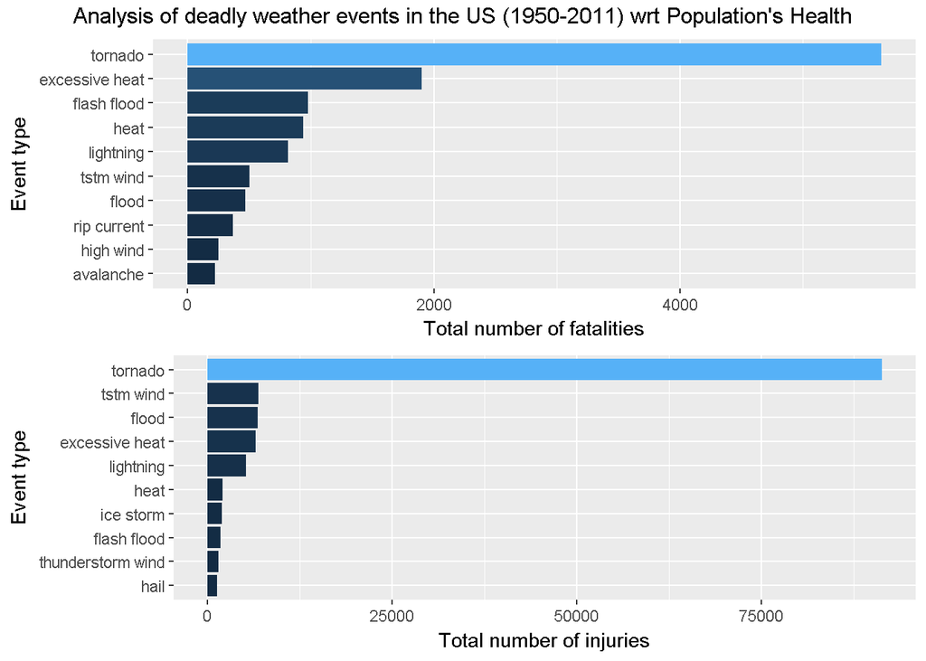

```r
#Effect of events on Health

p1 <- ggplot(data=fatal_events,aes(x=reorder(EVTYPE,fatalities),y=fatalities, fill = fatalities)) +
        geom_bar(stat = "identity") +
        coord_flip()+
        ylab("Total number of fatalities") +
        xlab("Event type") + theme(legend.position="none")

p2 <- ggplot(data=injury_events,
             aes(x=reorder(EVTYPE, injuries), y=injuries, fill=injuries)) +
        geom_bar(stat="identity") +
        coord_flip() +
        ylab("Total number of injuries") +
        xlab("Event type") +
        theme(legend.position="none")

grid.arrange(p1, p2, top="Analysis of deadly weather events in the US (1950-2011) wrt Population's Health")
```

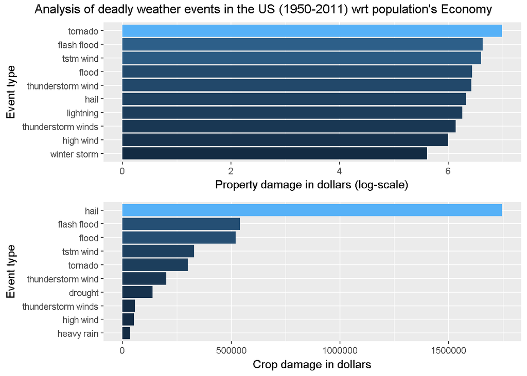

```r
#Effect of events on Economy

p3 <- ggplot(data=proploss_events,
             aes(x=reorder(EVTYPE, prop_loss), y=log10(prop_loss), fill=prop_loss )) +
        geom_bar(stat="identity") +
        coord_flip() +
        xlab("Event type") +
        ylab("Property damage in dollars (log-scale)") +
        theme(legend.position="none")

p4 <- ggplot(data=croploss_events,
             aes(x=reorder(EVTYPE, crop_loss), y=crop_loss, fill=crop_loss)) +
        geom_bar(stat="identity") +
        coord_flip() +
        xlab("Event type") +
        ylab("Crop damage in dollars") +
        theme(legend.position="none")

grid.arrange(p3, p4, top="Analysis of deadly weather events in the US (1950-2011) wrt population's Economy")
```

This concludes the analysis to find the effects of these severe weather conditions in US.